# Discriminant Analysis

Odinakachukwu Okechukwu Egwuekwe

## Part (a) Technical Report

Objective: To determine what factors influence whether a person has heart disease or not. The dataset contains 5420 obervations with 10 variables(6 Categorical and 4 Numeric Variables). An exploratory analysis of the dataset is performed to give a detailed overview.

# Summary Table for the Categorical Variables

| HeartDisease | n | prop | pct |
| --- | --- | --- | --- |
| No | 1503 | 0.277 | 27.7 |
| Yes | 3917 | 0.723 | 72.3 |

| Smoking | n | prop | pct |
| --- | --- | --- | --- |
| No | 2528 | 0.466 | 46.6 |
| Yes | 2892 | 0.534 | 53.4 |

| AlcoholDrinking | n | prop | pct |
| --- | --- | --- | --- |
| No | 5122 | 0.945 | 94.5 |
| Yes | 298 | 0.055 | 5.5 |

| Stroke | n | prop | pct |
| --- | --- | --- | --- |
| No | 4743 | 0.875 | 87.5 |
| Yes | 677 | 0.125 | 12.5 |

| Sex | n | prop | pct |
| --- | --- | --- | --- |
| Female | 2437 | 0.45 | 45 |
| Male | 2983 | 0.55 | 55 |

| AgeCategory | n | prop | pct |
| --- | --- | --- | --- |
| 18-24 | 121 | 0.022 | 2.2 |
| 25-29 | 104 | 0.019 | 1.9 |
| 30-34 | 134 | 0.025 | 2.5 |
| 35-39 | 160 | 0.030 | 3.0 |
| 40-44 | 184 | 0.034 | 3.4 |
| 45-49 | 216 | 0.040 | 4.0 |
| 50-54 | 318 | 0.059 | 5.9 |
| 55-59 | 497 | 0.092 | 9.2 |
| 60-64 | 617 | 0.114 | 11.4 |
| 65-69 | 711 | 0.131 | 13.1 |
| 70-74 | 854 | 0.158 | 15.8 |
| 75-79 | 654 | 0.121 | 12.1 |
| 80 or older | 850 | 0.157 | 15.7 |

## Boxplots

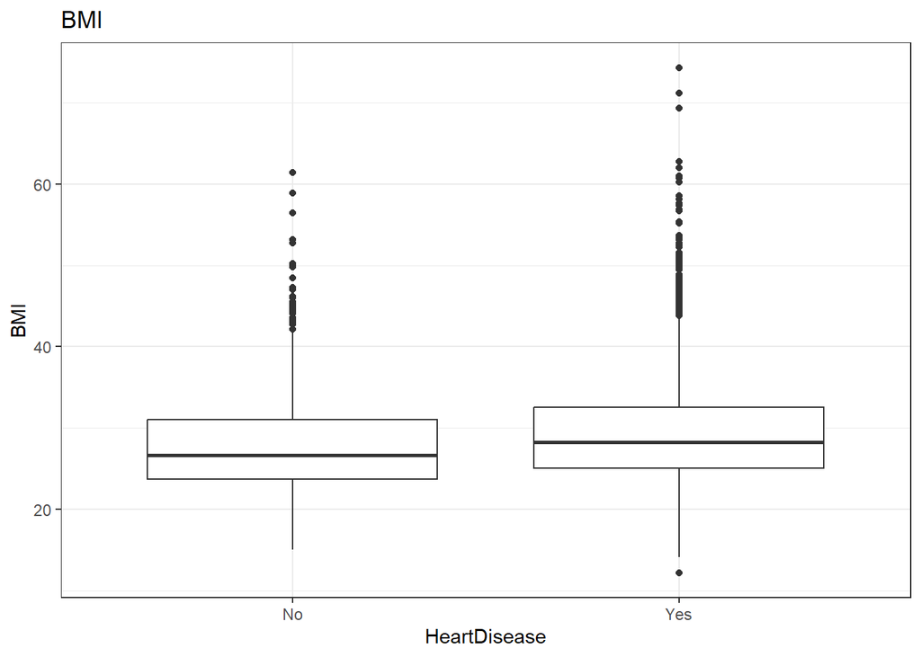

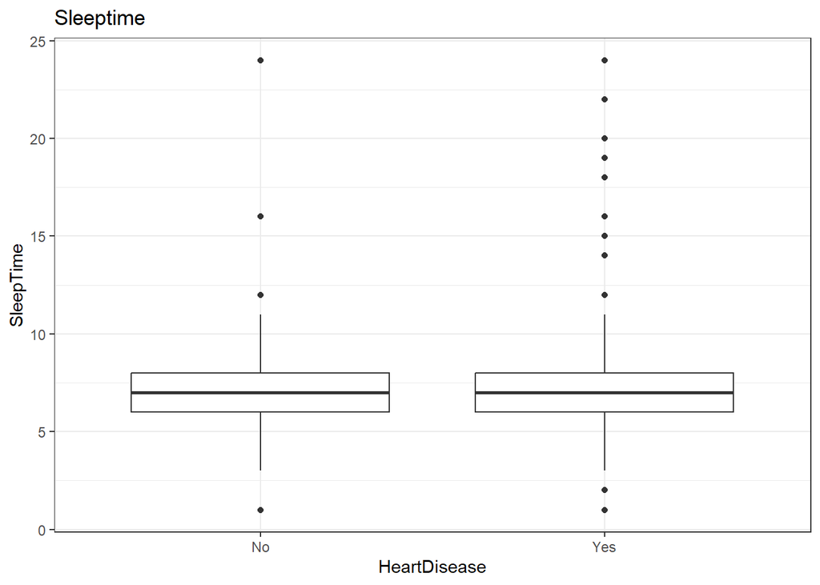

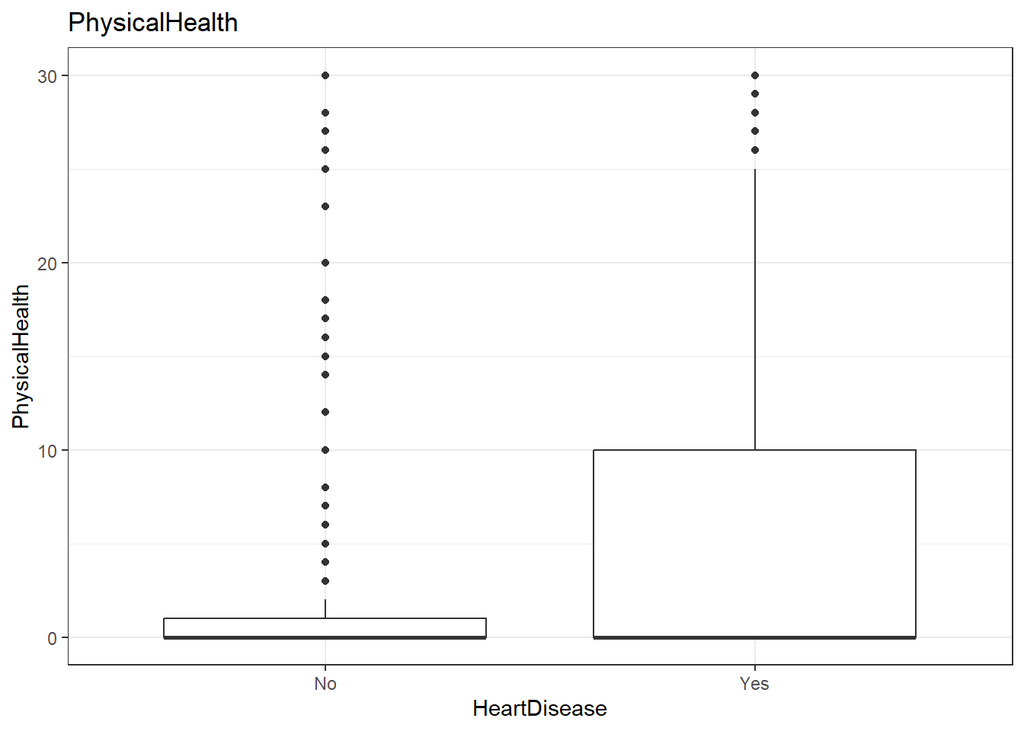

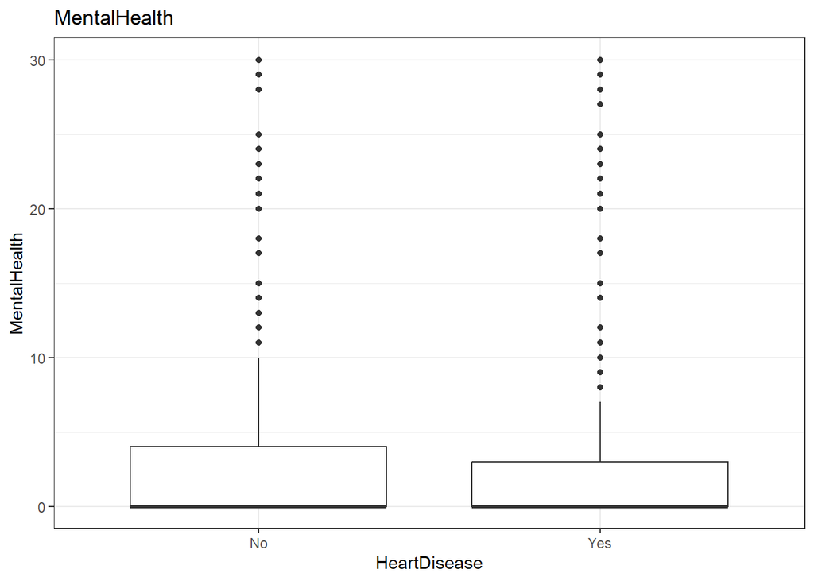

## Summary Statistics for Numerical Variables(BMI,Sleep time, Mental Health, Physical Health) by Heart Disease group

| BMI Summary by Heart Disease Status HeartDisease | BMI Summary by Heart Disease Status min | BMI Summary by Heart Disease Status max | BMI Summary by Heart Disease Status Q1 | BMI Summary by Heart Disease Status median | BMI Summary by Heart Disease Status Q3 | BMI Summary by Heart Disease Status mean | BMI Summary by Heart Disease Status sd |
| --- | --- | --- | --- | --- | --- | --- | --- |
| No | 15.00 | 61.44 | 23.69 | 26.63 | 31.055 | 27.99293 | 6.070109 |
| Yes | 12.21 | 74.33 | 25.06 | 28.27 | 32.550 | 29.36161 | 6.443873 |

| SleepTime Summary by Heart Disease Status HeartDisease | SleepTime Summary by Heart Disease Status min | SleepTime Summary by Heart Disease Status max | SleepTime Summary by Heart Disease Status Q1 | SleepTime Summary by Heart Disease Status median | SleepTime Summary by Heart Disease Status Q3 | SleepTime Summary by Heart Disease Status mean | SleepTime Summary by Heart Disease Status sd |
| --- | --- | --- | --- | --- | --- | --- | --- |
| No | 1 | 24 | 6 | 7 | 8 | 7.067864 | 1.381126 |
| Yes | 1 | 24 | 6 | 7 | 8 | 7.076079 | 1.782142 |

| Mental Health Summary by Heart Disease Status HeartDisease | Mental Health Summary by Heart Disease Status min | Mental Health Summary by Heart Disease Status max | Mental Health Summary by Heart Disease Status Q1 | Mental Health Summary by Heart Disease Status median | Mental Health Summary by Heart Disease Status Q3 | Mental Health Summary by Heart Disease Status mean | Mental Health Summary by Heart Disease Status sd |
| --- | --- | --- | --- | --- | --- | --- | --- |
| No | 0 | 30 | 0 | 0 | 4 | 3.971391 | 8.011384 |
| Yes | 0 | 30 | 0 | 0 | 3 | 4.454940 | 9.005748 |

| Physical Health Summary by Heart Disease Status HeartDisease | Physical Health Summary by Heart Disease Status min | Physical Health Summary by Heart Disease Status max | Physical Health Summary by Heart Disease Status Q1 | Physical Health Summary by Heart Disease Status median | Physical Health Summary by Heart Disease Status Q3 | Physical Health Summary by Heart Disease Status mean | Physical Health Summary by Heart Disease Status sd |
| --- | --- | --- | --- | --- | --- | --- | --- |
| No | 0 | 30 | 0 | 0 | 1 | 2.869594 | 7.219889 |
| Yes | 0 | 30 | 0 | 0 | 10 | 7.391882 | 11.268674 |

- The Respondents who have had Heart Disease have on average a higher BMI value compared to those who don’t have a heart disease history.
- The Respondents who have had Heart Disease have on average higher sick-days(Physically) compared to those who don’t have a heart disease history.
- The Respondents who have had Heart Disease have on average slightly higher sick-days(Mentally) compared to those who don’t have a heart disease history.
- The Respondents who have had Heart Disease have on average equal hours of sleep time compared to those who don’t have a heart disease history.

## Overall Summary for Numerical variables

| var | min | q25 | median | q75 | max | mean | sd |
| --- | --- | --- | --- | --- | --- | --- | --- |
| BMI | 12.21 | 24.6675 | 27.89 | 32.265 | 74.33 | 28.982068 | 6.371414 |
| MentalHealth | 0.00 | 0.0000 | 0.00 | 3.000 | 30.00 | 4.320849 | 8.743300 |
| PhysicalHealth | 0.00 | 0.0000 | 0.00 | 7.000 | 30.00 | 6.137823 | 10.502893 |
| SleepTime | 1.00 | 6.0000 | 7.00 | 8.000 | 24.00 | 7.073801 | 1.680433 |

The data were measured on different scales and it can be seen that there is high variability across the numerical groups, the data has to be standardized.

## Standardisation

| var | min | q25 | median | q75 | max | mean | sd |
| --- | --- | --- | --- | --- | --- | --- | --- |
| BMI | 1.9163722 | 3.871590 | 4.377364 | 5.0640252 | 11.666170 | 4.5487656 | 1 |
| MentalHealth | 0.0000000 | 0.000000 | 0.000000 | 0.3431199 | 3.431199 | 0.4941897 | 1 |
| PhysicalHealth | 0.0000000 | 0.000000 | 0.000000 | 0.6664830 | 2.856356 | 0.5843935 | 1 |
| SleepTime | 0.5950845 | 3.570507 | 4.165592 | 4.7606763 | 14.282029 | 4.2095095 | 1 |

As seen above the Data has been standardized with a standard deviation of 1 across the variables.

## Pairs plot to assess if any relationships exist between the $X_j$s and a correlation matrix to calculate the correlation coefficients between pairs of $X_j$s:

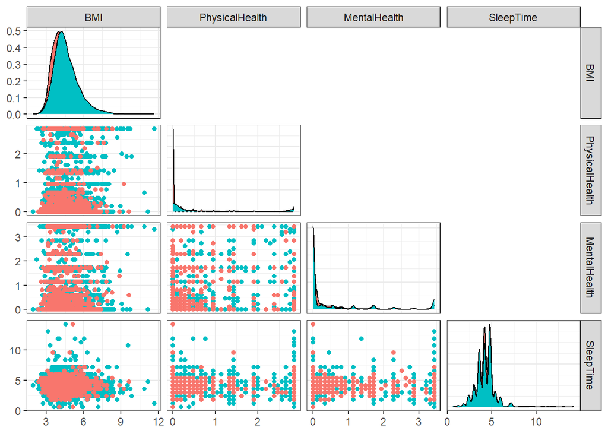

```
##                        BMI PhysicalHealth MentalHealth   SleepTime
## BMI             1.00000000     0.11129881   0.07620295 -0.05393360
## PhysicalHealth  0.11129881     1.00000000   0.34437743 -0.08803783
## MentalHealth    0.07620295     0.34437743   1.00000000 -0.12880543
## SleepTime      -0.05393360    -0.08803783  -0.12880543  1.00000000
```

-The following Deductions were made from the exploratory analysis

- The proportion of Respondents that have ever reported having coronary heart disease(CHD) or myocardial infection (MI) =(0.723) is approximately three times the proportion of Respondents without Heart Disease History(0.277)
- The box plots for “Sleep Time” and BMI are reasonably symmetric in contrast to the box-plots for Mental Health and Physical Activity which is heavily skewed with extreme outliers. From the data it could be related to the heavy presence(Mode) of 0 in both variables.
- The BMI variable appears to have the most significant discrepancy between the medians of both groups(i.e.,=1.64), and respondents with a heart disease history have a higher median value of 28.27 compared to Respondents without heart disease=26.63. As a result, the BMI variable could be a useful predictor.
- There is minimal correlation between “Sleep time” and other variables and close to a moderate correlation between “Mental Health” and “Physical Health” r=0.34
- Overall, there is a close to moderate presence of outliers in the dataset.

## LOGISTIC REGRESSION

With G=2, large ‘n’, and uncorrelated Variables and relaxing the assumptions of Multivariate Normality, We employ Logistic Regression to classify the respondents.

#fitting the Logistic Model using the uncorrelated variables

```r
glm.fit = glm(HeartDisease.f~BMI+Smoking.f+AlcoholDrinking.f+Stroke.f+PhysicalHealth+MentalHealth+Sex.f+AgeCategory.f+SleepTime, data=Hdd, family="binomial")

summary(glm.fit)
```

```
##
## Call:
## glm(formula = HeartDisease.f ~ BMI + Smoking.f + AlcoholDrinking.f +
##     Stroke.f + PhysicalHealth + MentalHealth + Sex.f + AgeCategory.f +
##     SleepTime, family = "binomial", data = Hdd)
##
## Coefficients:
##                          Estimate Std. Error z value Pr(>|z|)
## (Intercept)              -3.60308    0.38599  -9.335  < 2e-16 ***
## BMI                       0.29288    0.03920   7.471 7.96e-14 ***
## Smoking.fYes              0.54251    0.07373   7.358 1.87e-13 ***
## AlcoholDrinking.fYes     -0.49292    0.14893  -3.310 0.000934 ***
## Stroke.fYes               1.69617    0.18087   9.378  < 2e-16 ***
## PhysicalHealth            0.38466    0.04859   7.917 2.43e-15 ***
## MentalHealth              0.13217    0.04324   3.056 0.002241 **
## Sex.fMale                 0.64103    0.07398   8.665  < 2e-16 ***
## AgeCategory.f25-29        0.48888    0.39225   1.246 0.212632
## AgeCategory.f30-34        0.57764    0.36627   1.577 0.114776
## AgeCategory.f35-39        1.01181    0.34855   2.903 0.003697 **
## AgeCategory.f40-44        1.20950    0.33977   3.560 0.000371 ***
## AgeCategory.f45-49        1.36813    0.33432   4.092 4.27e-05 ***
## AgeCategory.f50-54        2.09556    0.32239   6.500 8.03e-11 ***
## AgeCategory.f55-59        2.54941    0.31603   8.067 7.20e-16 ***
## AgeCategory.f60-64        2.76532    0.31343   8.823  < 2e-16 ***
## AgeCategory.f65-69        3.00587    0.31223   9.627  < 2e-16 ***
## AgeCategory.f70-74        3.36145    0.31240  10.760  < 2e-16 ***
## AgeCategory.f75-79        3.73693    0.32272  11.579  < 2e-16 ***
## AgeCategory.f80 or older  4.20547    0.32093  13.104  < 2e-16 ***
## SleepTime                -0.09582    0.03858  -2.484 0.013002 *
## ---
## Signif. codes:  0 '***' 0.001 '**' 0.01 '*' 0.05 '.' 0.1 ' ' 1
##
## (Dispersion parameter for binomial family taken to be 1)
##
##     Null deviance: 6399.8  on 5419  degrees of freedom
## Residual deviance: 4808.4  on 5399  degrees of freedom
## AIC: 4850.4
##
## Number of Fisher Scoring iterations: 5
```

The $X_J$s are significant in the model as the P-values are very small giving indication that these variables may be useful for discriminating between the groups and are strongly associated with the probability of having a Heart Disease.

-The following can be concluded from the logistic coefficients